[figure not shown]

# Police stops and frisks in New York City

This dashboard provides data of the **Stop and Frisk Program in New York City**. Stop and frisk is the practice of temporarily detaining, questioning, and searching suspects on the street for weapons and suspicious materials. Since its introduction in the early 1980s, the program has been criticized as increasing racial profiling and police-initiated violence.

This dashboard used data of the stop and frisk program to explore the relationship between a suspect’s race and their likelihood of being stopped and frisked by a police officers.

The original data come from the New York City Police Department website in separate annual files. I combined those files to obtain a complete set of data covering the **2006 - 2021** period. This combined data set contains over four million rows, which made it very difficult to use. I obtained a randomized sample of 160,000 stop incidences and used this sample to complete this dashboard.

# Racial breakdown

### Racial breakdown of stop targets in NYC

Black and people with Hispanic origin make up a majority of stops in any given year. The program became unpopular after its peak in 2011 when NYPD encountered criticism for over 99% of non-lethal violence in the city being committed by the NYPD itself.

[interactive chart not shown]

Black and people with Hispanic origin make up a majority of stops in any given year. The program became unpopular after its peak in 2011 when NYPD encountered criticism for over 99% of non-lethal violence in the city being committed by the NYPD itself.

Blacks and Hispanics account for a much higher portion of targets in stop-and-frisk than represented in the population

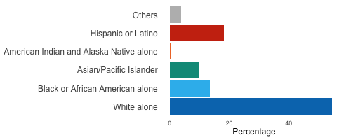

### Likelihood of frisk incidence

Once stopped, Blacks and Hispanics are also more likely frisked for a variety of reasons.

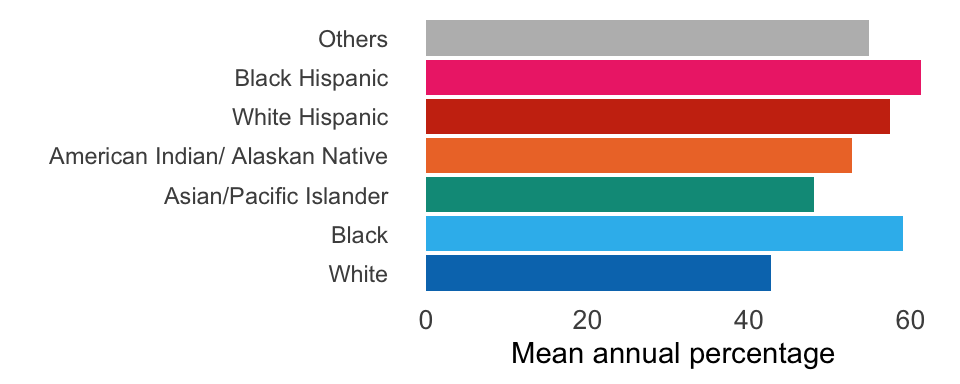